# NYS BRFSS County-Level E-Cigarette Use Map

Oh, Eun Jeong

2026-05-22

# 1 Overview

This page presents an illustrative R workflow for visualizing county-level e-cigarette use in New York State (NYS) using 2021 NYS BRFSS data. The examples include an interactive county-level map, a bubble map, and a county ranking plot created using the R packages leaflet, ggplot2, sf, and tigris.

# 2 NYS BRFSS 2021 Data

The NYS BRFSS county-level 2021 e-cigarette use data are obtained from the NYS Open Data API in .csv format.

```r
# load packages
library(tidyverse)  # data wrangling and cleaning
library(sf)         # spatial data handling
library(tigris)     # county boundary data
library(scales)     # percentage and number formatting
library(ggplot2)    # static plots
library(leaflet)    # interactive maps

options(tigris_use_cache = TRUE)  # cache tigris map data

# save the brfss csv api link
brfss_url_csv = "https://health.data.ny.gov/resource/jsy7-eb4n.csv?$limit=50000"

tmp_csv = tempfile(fileext = ".csv")

# download brfss data to a temporary csv file
download.file(
  url = brfss_url_csv,
  destfile = tmp_csv,
  mode = "wb",
  quiet = TRUE,
  method = "libcurl"
)

# read the downloaded brfss csv file
brfss_all = read_csv(
  tmp_csv,
  show_col_types = FALSE,
  progress = FALSE
)

# define a helper function to standardize county names
clean_county = function(x){
  x %>%
    str_remove(" County$") %>%
    str_replace_all("\\.", "") %>%
    str_squish() %>%
    str_to_title()
}

# filter to 2021 county-level e-cigarette use records and clean fields
brfss_county = brfss_all %>%
  filter(
    health_indicator_short_name == "e-Cigarettes",
    geography == "County",
    as.character(years) == "2021"
  ) %>%
  transmute(
    county = clean_county(region_county),
    sample_n = sample_size_n,
    rate_num = unadjusted_rate,
    ci_low_num = cl_95_lower_unadjusted,
    ci_high_num = cl_95_upper_unadjusted
  ) %>%
  mutate(
    use_rate = rate_num / 100,
    ci_low = ci_low_num / 100,
    ci_high = ci_high_num / 100
  ) %>%
  filter(!is.na(use_rate))

# download and prepare nys county boundary data
nys_sf = counties(state = "NY", cb = TRUE, resolution = "5m") %>%
  st_transform(crs = 4326) %>%
  transmute(
    county = clean_county(NAME),
    geometry = geometry
  )

# join brfss county data to the nys map data
nys_map = nys_sf %>%
  left_join(brfss_county, by = "county")

# calculate county centroid coordinates for the bubble map
nys_centroids = nys_map %>%
  st_point_on_surface() %>%
  mutate(
    lon = st_coordinates(.)[, 1],
    lat = st_coordinates(.)[, 2]
  ) %>%
  st_drop_geometry()
```

# 3 Code Availability

The data access and preparation code is shown above for transparency. The visualization code used to generate the maps and ranking plot is not displayed in the rendered page, but it is available upon request.

# 4 Maps

Here, three figures are created:

1. Interactive map of county-level e-cigarette use
2. Bubble map showing e-cigarette use rate and sample size
3. Ranking plot by county

## 4.1 Interactive map

*Note: Counties with missing e-cigarette use estimates are shown in black.*

[interactive chart not shown]

## 4.2 Bubble map

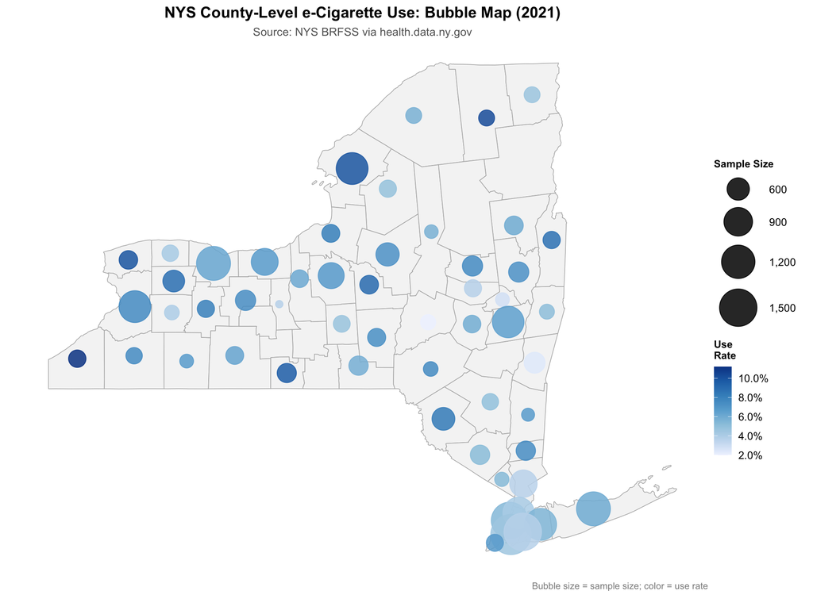

## 4.3 Ranking plot

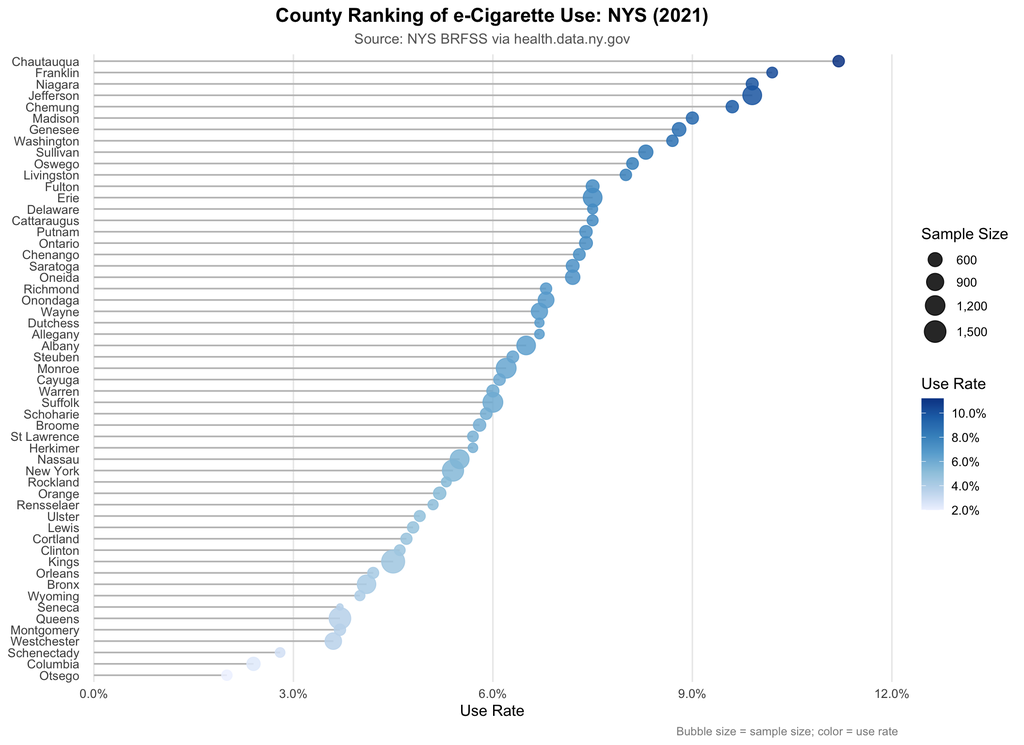

# 5 Contact

Questions, suggestions, and collaboration inquiries are welcome. Please feel free to contact me if you are interested in adapting this workflow to other public health datasets or research settings.

**Eun Jeong Oh, PhD**  
Assistant Professor of Biostatistics, Research Intelligence  
Northwell Health  
GitHub: https://github.com/oheunj  
Email: eoh2 [at] northwell [dot] edu

© 2026 Eun Jeong Oh. All rights reserved.